# Perfect Plots: bar plots

```python
import pandas as pd
import matplotlib.pyplot as plt
import numpy as np
import matplotlib.patches as mpatches
```

# Car statistics

```python
# Prepare Data
df = pd.read_csv('c:/1/mpg_ggplot2.txt')

df2 = df.pivot_table(index='manufacturer',values='model', aggfunc='count').reset_index()
df2 = df2.rename(columns={'model':'counts'})

# bardzo ważne żeby wykres był ładnie posortowany
df2.sort_values('counts', ascending=False, inplace=True)
df2.reset_index(inplace=True)
df2
```

|  | index | manufacturer | counts |
| --- | --- | --- | --- |
| 0 | 2 | dodge | 37 |
| 1 | 13 | toyota | 34 |
| 2 | 14 | volkswagen | 27 |
| 3 | 3 | ford | 25 |
| 4 | 1 | chevrolet | 19 |
| 5 | 0 | audi | 18 |
| 6 | 5 | hyundai | 14 |
| 7 | 12 | subaru | 14 |
| 8 | 10 | nissan | 13 |
| 9 | 4 | honda | 9 |
| 10 | 6 | jeep | 8 |
| 11 | 11 | pontiac | 5 |
| 12 | 7 | land rover | 4 |
| 13 | 9 | mercury | 4 |
| 14 | 8 | lincoln | 3 |

```python
df.head(3)
```

|  | manufacturer | model | displ | year | cyl | trans | drv | cty | hwy | fl | class |
| --- | --- | --- | --- | --- | --- | --- | --- | --- | --- | --- | --- |
| 0 | audi | a4 | 1.8 | 1999 | 4 | auto(l5) | f | 18 | 29 | p | compact |
| 1 | audi | a4 | 1.8 | 1999 | 4 | manual(m5) | f | 21 | 29 | p | compact |
| 2 | audi | a4 | 2.0 | 2008 | 4 | manual(m6) | f | 20 | 31 | p | compact |

```python
KAT = df.pivot_table(index =['hwy', 'cty'], values ='model', aggfunc='count'  ).reset_index()
KAT = KAT.rename(columns ={'model':'counts'})
KAT.head()
```

|  | hwy | cty | counts |
| --- | --- | --- | --- |
| 0 | 12 | 9 | 5 |
| 1 | 14 | 11 | 2 |
| 2 | 15 | 11 | 10 |
| 3 | 16 | 11 | 3 |
| 4 | 16 | 12 | 2 |

#### Stripplot

Size of circle is bigger as more points overlap.

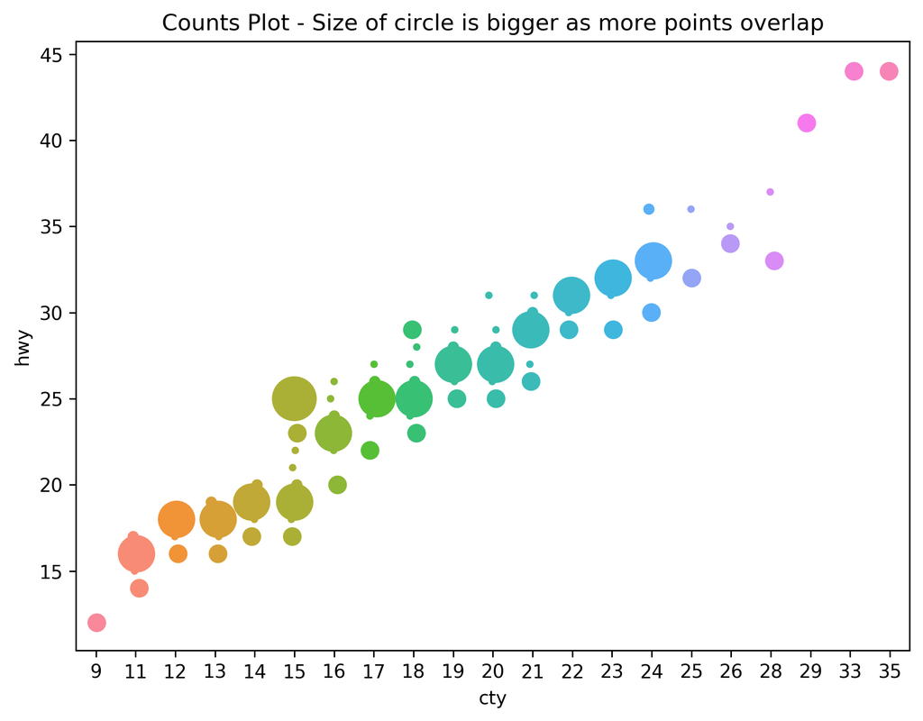

```python
import seaborn as sns

# Draw Stripplot
fig, ax = plt.subplots(figsize=(8,6), dpi= 280)
sns.stripplot(KAT.cty, KAT.hwy, size=KAT.counts*2, ax=ax)

# Decorations
plt.title('Counts Plot - Size of circle is bigger as more points overlap', fontsize=12)
plt.show()
```

## Plot Bars

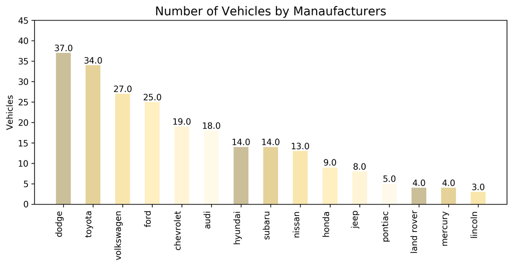

```python
# Plot Bars
plt.figure(figsize=(10,4), dpi= 280)
plt.bar(df2['manufacturer'], df2['counts'], color=['#7f6000','#bf9000','#f1c232','#ffd966','#ffe599','#fff2cc'], alpha=0.4, width=.5)
for i, val in enumerate(df2['counts'].values):
    plt.text(i, val, float(val), horizontalalignment='center', verticalalignment='bottom', fontdict={'fontweight':500, 'size':10})

# Decoration
plt.gca().set_xticklabels(df2['manufacturer'], rotation=90, horizontalalignment= 'right')
plt.title("Number of Vehicles by Manaufacturers", fontsize=14)
plt.ylabel('Vehicles')
plt.ylim(0, 45)
plt.show()
```

# Trigger

Dane do wykresu x1 opis x2 dane liczbowe

```python
name = df2.manufacturer
x = df2.counts
```

```python
ylabel = 'Vehicles'
title = 'Number of Vehicles by Manaufacturers'
```

```python
def bar1(name, x, ylabel, title):
    # Plot Bars
    plt.figure(figsize=(10,4), dpi= 280)
    plt.bar(name, x, color=['#0c343d','#134f5c','#45818e','#76a5af','#a2c4c9','#d0e0e3'], alpha=0.4, width=.5)
    for i, val in enumerate(df2['counts'].values):
        plt.text(i, val, float(val), horizontalalignment='center', verticalalignment='bottom', fontdict={'fontweight':500, 'size':10})

# Decoration
    plt.gca().set_xticklabels(df2['manufacturer'], rotation=90, horizontalalignment= 'right')
    plt.title(title, fontsize=14)
    plt.ylabel(ylabel)
    plt.ylim(0, 45)
    plt.show()
```

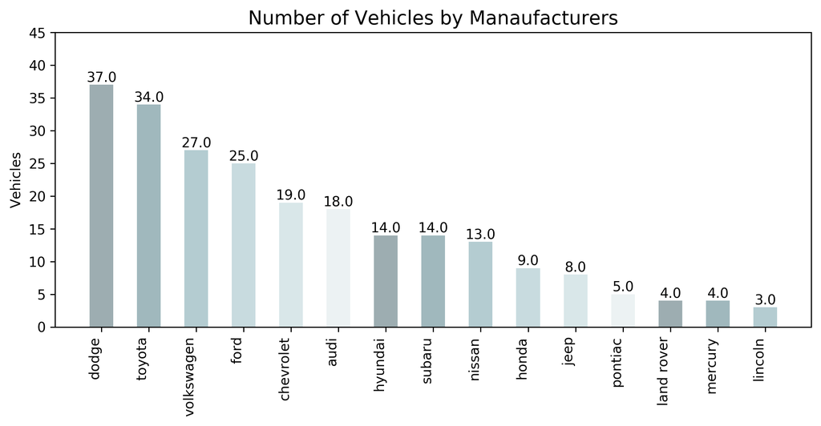

```python
bar1(name, x, ylabel, title)
```

https://yagisanatode.com/2019/08/06/google-apps-script-hexadecimal-color-codes-for-google-docs-sheets-and-slides-standart-palette/

# colors = ['#274e13','#6aa84f','#93c47d', '#b6d7a8','#d9ead3','#b7b7b7','#38761d'] #green

# colors = ['#0c343d','#134f5c','#45818e','#76a5af','#a2c4c9','#d0e0e3'] #cyan

# colors = ['#7f6000','#bf9000','#f1c232','#ffd966','#ffe599','#fff2cc'] #yelow

# colors = ['#4c1130','#a64d79','#c27ba0','#d5a6bd','#ead1dc','#741b47',] #magenta

# colors = ['#e6b8af','#b6d7a8','#e06666','#747574','#ffd966','#ffcc99','#ea9999']

# colors = ['#93c47d','#b6d7a8','#d9ead3','#d0e0e3','#a2c4c9','#76a5af']

colors = ['#c27ba0','#d5a6bd','#ead1dc','#ffffff','#a64d79','#d9d2e9','#b4a7d6'] #purple

# colors = ['#cfe2f3','#9fc5e8','#6fa8dc'] #blue

# colors = ['#d9ead3','#b6d7a8','#93c47d','#6aa84f']

# colors = ['#ff0000','#434343','#666666','#999999','#b7b7b7','#cccccc','#d9d9d9','#efefef','#ffffff','#f3f3f3'] #=> niemieckie czasopismo

## Airports

```python
df3 = pd.read_csv('c:/1/airports.csv')
df3.head(3)
```

|  | id | ident | type | name | latitude_deg | longitude_deg | elevation_ft | continent | iso_country | iso_region | municipality | scheduled_service | gps_code | iata_code | local_code | home_link | wikipedia_link | keywords |
| --- | --- | --- | --- | --- | --- | --- | --- | --- | --- | --- | --- | --- | --- | --- | --- | --- | --- | --- |
| 0 | 6523 | 00A | heliport | Total Rf Heliport | 40.070801 | -74.933601 | 11.0 | NaN | US | US-PA | Bensalem | no | 00A | NaN | 00A | NaN | NaN | NaN |
| 1 | 323361 | 00AA | small_airport | Aero B Ranch Airport | 38.704022 | -101.473911 | 3435.0 | NaN | US | US-KS | Leoti | no | 00AA | NaN | 00AA | NaN | NaN | NaN |
| 2 | 6524 | 00AK | small_airport | Lowell Field | 59.949200 | -151.695999 | 450.0 | NaN | US | US-AK | Anchor Point | no | 00AK | NaN | 00AK | NaN | NaN | NaN |

```python
PPS = df3.pivot_table(index = 'type', values = 'name', aggfunc = 'count').reset_index()
PPS = PPS.rename(columns={'name':'counts'})
# bardzo ważne żeby wykres był ładnie posortowany
PPS.sort_values('counts', ascending=False, inplace=True)
PPS.reset_index(inplace=True)
PPS
```

|  | index | type | counts |
| --- | --- | --- | --- |
| 0 | 6 | small_airport | 33942 |
| 1 | 2 | heliport | 11248 |
| 2 | 4 | medium_airport | 4550 |
| 3 | 1 | closed | 3529 |
| 4 | 5 | seaplane_base | 1015 |
| 5 | 3 | large_airport | 624 |
| 6 | 0 | balloonport | 23 |

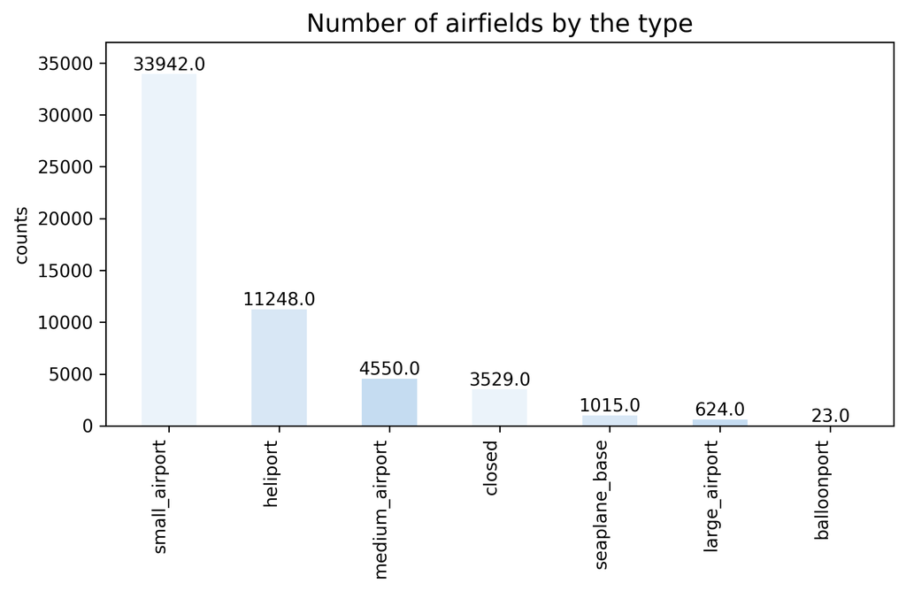

```python
# Plot Bars
plt.figure(figsize=(8,4), dpi= 280)
plt.bar(PPS['type'], PPS['counts'], color=['#cfe2f3','#9fc5e8','#6fa8dc'], alpha=0.4, width=.5)
#numery na słupakach

for i, val in enumerate(PPS['counts'].values):
    plt.text(i, val, float(val), horizontalalignment='center', verticalalignment='bottom', fontdict={'fontweight':500, 'size':10})

# Decoration
plt.gca().set_xticklabels(PPS['type'], rotation=90, horizontalalignment= 'right')
plt.title("Number of airfields by the type", fontsize=14)
plt.ylabel('counts')
plt.ylim(0, 37000)
plt.show()
```

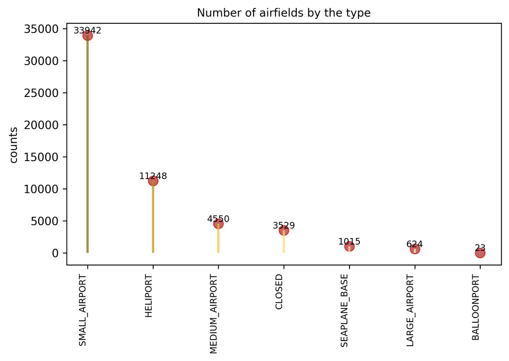

```python
import matplotlib.pyplot as plt
color=['#7f6000','#bf9000','#f1c232','#ffd966','#ffe599','#fff2cc']

# Draw plot
fig, ax = plt.subplots(figsize=(7,4), dpi= 280)
ax.vlines(x=PPS.index, ymin=0, ymax=PPS.counts, color=color, alpha=0.7, linewidth=2)
ax.scatter(x=PPS.index, y=PPS.counts, s=75, color='firebrick', alpha=0.7)

# Title, Label, Ticks and Ylim
ax.set_title('Number of airfields by the type', fontdict={'size':10})
ax.set_ylabel('counts')
ax.set_xticks(PPS.index)
ax.set_xticklabels(PPS.type.str.upper(), rotation=90, fontdict={'horizontalalignment': 'right', 'size':8})
#ax.set_ylim(0, 30)

# Annotate
for row in PPS.itertuples():
    ax.text(row.Index, row.counts+.5, s=round(row.counts, 2), horizontalalignment= 'center', verticalalignment='bottom', fontsize=8)

plt.show()
```

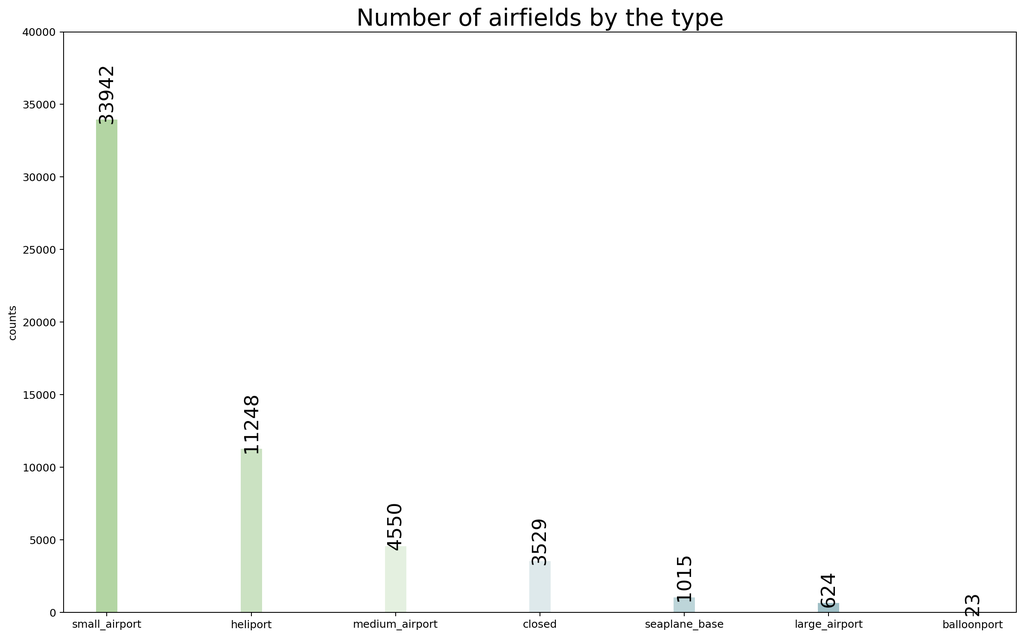

```python
## Draw plot
import matplotlib.patches as patches
color = ['#93c47d','#b6d7a8','#d9ead3','#d0e0e3','#a2c4c9','#76a5af']



fig, ax = plt.subplots(figsize=(16,10), facecolor='white', dpi= 180)
ax.vlines(x=PPS.type, ymin=0, ymax=PPS.counts, color=color, alpha=0.7, linewidth=20)

# Annotate Text
for i, kot in enumerate(PPS.counts):
    ax.text(i, kot+0.5, round(kot, 1), horizontalalignment='center', fontsize=18, rotation=90)


# Title, Label, Ticks and Ylim
ax.set_title('Number of airfields by the type', fontdict={'size':22})
ax.set(ylabel='counts', ylim=(0, 40000))
#plt.xticks(PPS.type, PPS.counts.str.upper(), rotation=30, horizontalalignment='right', fontsize=12)

# Add patches to color the X axis labels
#p1 = patches.Rectangle((.57, -0.005), width=.33, height=.13, alpha=.1, facecolor='grey', transform=fig.transFigure)
#p2 = patches.Rectangle((.124, -0.005), width=.446, height=.13, alpha=.1, facecolor='yellow', transform=fig.transFigure)
#fig.add_artist(p1)
#fig.add_artist(p2)
plt.show()
```

## World Happiness Report

```python
df4 = pd.read_csv('c:/1/WorldHappinessReport.csv')
df4.head(3)# Draw plot
```

|  | Unnamed: 0 | Country | Region | Happiness Rank | Happiness Score | Economy (GDP per Capita) | Family | Health (Life Expectancy) | Freedom | Trust (Government Corruption) | Generosity | Dystopia Residual | Year |
| --- | --- | --- | --- | --- | --- | --- | --- | --- | --- | --- | --- | --- | --- |
| 0 | 0 | Afghanistan | Southern Asia | 153.0 | 3.575 | 0.31982 | 0.30285 | 0.30335 | 0.23414 | 0.09719 | 0.36510 | 1.95210 | 2015.0 |
| 1 | 1 | Albania | Central and Eastern Europe | 95.0 | 4.959 | 0.87867 | 0.80434 | 0.81325 | 0.35733 | 0.06413 | 0.14272 | 1.89894 | 2015.0 |
| 2 | 2 | Algeria | Middle East and Northern Africa | 68.0 | 5.605 | 0.93929 | 1.07772 | 0.61766 | 0.28579 | 0.17383 | 0.07822 | 2.43209 | 2015.0 |

```python
PKP = df4.pivot_table(index='Region', values='Happiness Score', aggfunc= 'mean' ).reset_index()
PKP['Happiness Score'] = np.round(PKP['Happiness Score'], decimals=2)

# bardzo ważne żeby wykres był ładnie posortowany
PKP.sort_values('Happiness Score', inplace=True)
PKP.reset_index(inplace=True)

PKP
```

|  | index | Region | Happiness Score |
| --- | --- | --- | --- |
| 0 | 8 | Sub-Saharan Africa | 4.15 |
| 1 | 7 | Southern Asia | 4.59 |
| 2 | 6 | Southeastern Asia | 5.36 |
| 3 | 1 | Central and Eastern Europe | 5.37 |
| 4 | 4 | Middle East and Northern Africa | 5.39 |
| 5 | 2 | Eastern Asia | 5.64 |
| 6 | 3 | Latin America and Caribbean | 6.07 |
| 7 | 9 | Western Europe | 6.69 |
| 8 | 5 | North America | 7.23 |
| 9 | 0 | Australia and New Zealand | 7.30 |

colors = ['#d9ead3','#b6d7a8','#93c47d','#6aa84f']

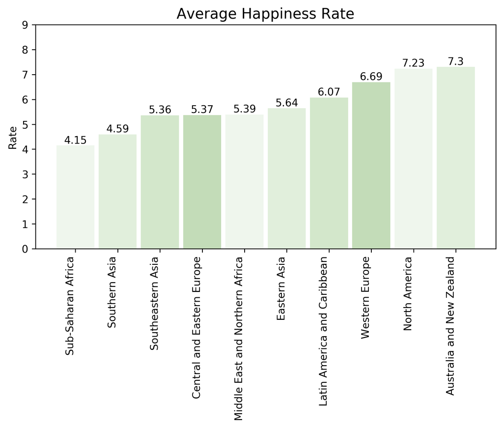

```python
# Plot Bars
plt.figure(figsize=(8,4), dpi= 280)
plt.bar(PKP['Region'], PKP['Happiness Score'], color=['#d9ead3','#b6d7a8','#93c47d','#6aa84f'], alpha=0.4, width=.9)
#numery na słupakach

for i, val in enumerate(PKP['Happiness Score'].values):
    plt.text(i, val, float(val), horizontalalignment='center', verticalalignment='bottom', fontdict={'fontweight':500, 'size':10})

# Decoration
plt.gca().set_xticklabels(PKP['Region'], rotation=90, horizontalalignment= 'right')
plt.title("Average Happiness Rate", fontsize=14)
plt.ylabel('Rate' )
plt.ylim(0, 9)
plt.show()
```

```python
PKP['HappS'] =PKP['Happiness Score']
```

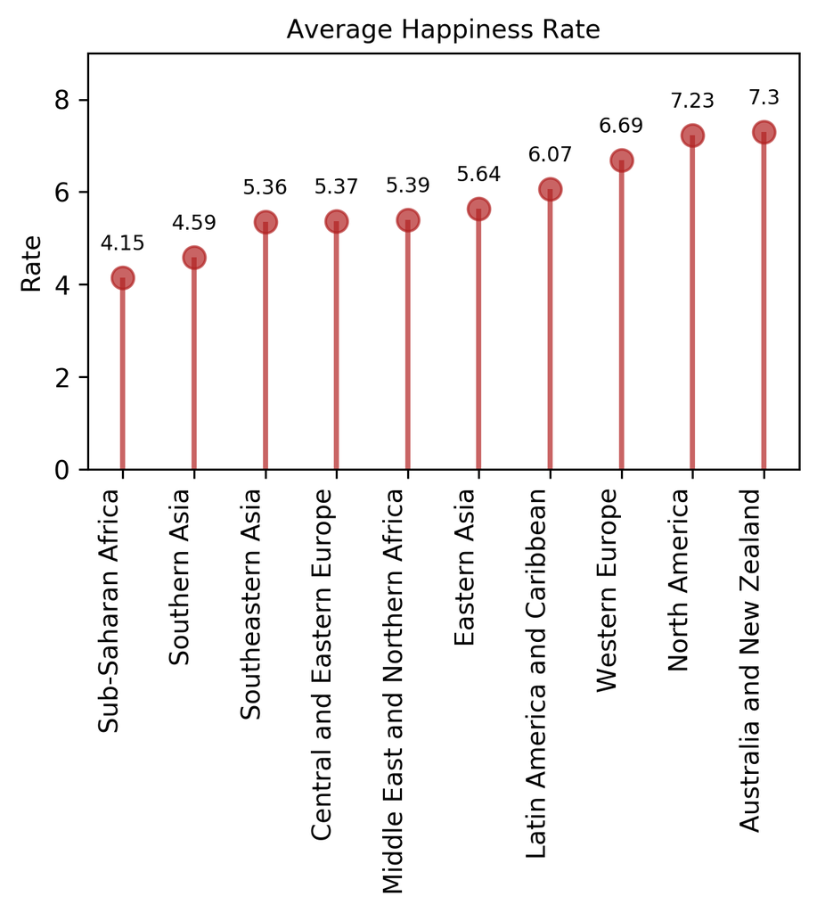

```python
import matplotlib.pyplot as plt
# Draw plot
fig, ax = plt.subplots(figsize=(5,3), dpi= 280)
ax.vlines(x=PKP.index, ymin=0, ymax=PKP['HappS'], color='firebrick', alpha=0.7, linewidth=2)
ax.scatter(x=PKP.index, y=PKP['HappS'], s=75, color='firebrick', alpha=0.7)

# Title, Label, Ticks and Ylim
ax.set_title('Average Happiness Rate', fontdict={'size':10})
ax.set_ylabel('Rate')
ax.set_xticks(PKP.index)
#ax.set_xticklabels(PKP.type.str.upper(), rotation=90, fontdict={'horizontalalignment': 'right', 'size':8})
ax.set_ylim(0, 9)

# Annotate
for row in PKP.itertuples():
    ax.text(row.Index, row.HappS+.5, s=round(row.HappS, 2), horizontalalignment= 'center', verticalalignment='bottom', fontsize=8)

plt.gca().set_xticklabels(PKP['Region'], rotation=90, horizontalalignment= 'right')
plt.show()
```

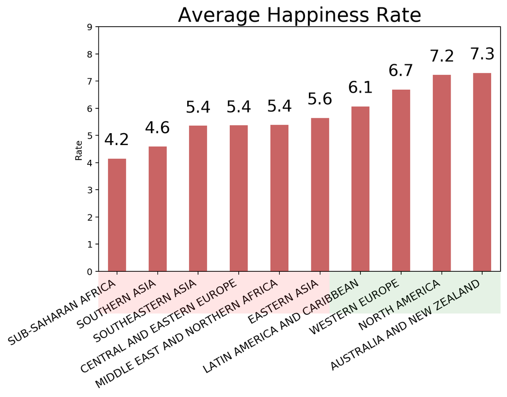

```python
## Draw plot
import matplotlib.patches as patches

fig, ax = plt.subplots(figsize=(8,5), facecolor='white', dpi= 180)
ax.vlines(x=PKP.index, ymin=0, ymax=PKP['Happiness Score'], color='firebrick', alpha=0.7, linewidth=20)

# Annotate Text
for i, kot in enumerate(PKP['Happiness Score']):
    ax.text(i, kot+0.5, round(kot, 1), horizontalalignment='center', fontsize=18, rotation=0)


# Title, Label, Ticks and Ylim
ax.set_title('Average Happiness Rate', fontdict={'size':22})
ax.set(ylabel='Rate', ylim=(0, 9))
plt.xticks(PKP.index, PKP.Region.str.upper(), rotation=30, horizontalalignment='right', fontsize=12)

# Add patches to color the X axis labels
p1 = patches.Rectangle((.57, -0.005), width=.33, height=.13, alpha=.1, facecolor='green', transform=fig.transFigure)
p2 = patches.Rectangle((.124, -0.005), width=.446, height=.13, alpha=.1, facecolor='red', transform=fig.transFigure)
fig.add_artist(p1)
fig.add_artist(p2)
plt.show()
```